# Simple Linear Regression

**Least Squares Regression**  
The line that minimizes the sum of the squared differences

`geo_smooth("lm", se = TRUE/FALSE)`

Generic Statistical Model: response = f(explanatory) + noise

Generic Linear Model: intercept + (slope * explanatory) + noise

$Y = b_0+ b_1* X$

**Residuals**

Y-hat (Y^) is the expected value given a corresponding x value.  
In other words, it is the estimated value.

Y = the observed value.

e = Y - Y^

**Galton’s Regression to the mean**

A very important statistical concept which argues that extreme variables tend to be closer to the mean upon subsequent measurements.

example: height of tall parents’ children tend to be taller than average but not as tall as their parents.

## Linear Modeling

`lm` is an object of class type lm.

`fitted.values` returns the Y^ corresponding to each observation. NA value are removed from the lm and removed, therefore, in some cases, the fitted values nay not return the same length as the original data frame.

`residuals` can be retrieved using `residuals(lm)`

**The broom package is useful** for various modeling features.

`augment()` will apply the per observation statistics to a model in a tidy fashion.  
*useful to know: augment has replaced the outdated* **fortify** *function which you may still see floating around older tutorials and examples on the internet/elsewhere.*

Here’s an example:

```r
library(broom)
library(tidyverse)

mod <- lm(data = diamonds, price ~ carat)
diamonds_tidy <- augment(mod)
glimpse(diamonds_tidy)
```

```
Observations: 53,940
Variables: 9
$ price      <int> 326, 326, 327, 334, 335, 336, 336, 337, 337, 338...
$ carat      <dbl> 0.23, 0.21, 0.23, 0.29, 0.31, 0.24, 0.24, 0.26, ...
$ .fitted    <dbl> -472.382688, -627.511200, -472.382688, -6.997151...
$ .se.fit    <dbl> 10.405828, 10.623347, 10.405828, 9.772834, 9.569...
$ .resid     <dbl> 798.3827, 953.5112, 799.3827, 340.9972, 186.8686...
$ .hat       <dbl> 4.515399e-05, 4.706148e-05, 4.515399e-05, 3.9827...
$ .sigma     <dbl> 1548.572, 1548.571, 1548.572, 1548.576, 1548.576...
$ .cooksd    <dbl> 6.001647e-06, 8.922178e-06, 6.016690e-06, 9.6567...
$ .std.resid <dbl> 0.51557559, 0.61575429, 0.51622136, 0.22020685, ...
```

Making predictions on data outside of our sample data set is a key concept of machine learning.

```r
mean.price <- mean(diamonds_tidy$price)
sd.price <- sd(diamonds_tidy$price)
mean.carat <- mean(diamonds_tidy$carat)
sd.carat <- sd(diamonds_tidy$carat)

#We have a data set of carat sizes that we want to estimate the prices for.
sample_data <- data.frame(carat = rnorm( 500, mean = 2.5, sd = 1))


sample_data <- sample_data %>%
  mutate(predictions = predict(mod, newdata = sample_data))

summary(sample_data)

sample_data %>%
  ggplot(aes(x = carat, y = predictions))+
  geom_point() +
  geom_abline(slope = slope)+
  geom_smooth(method = "lm")
```

[output not shown]

### Quantification of Model Fit

SSE = sum of squared errors

Residual Standard Error (in R) is the RMSE, or Root Mean Squared Error

- Standard Deviations of the residuals
- In which we divide by the degrees of freedom rather than the number of observations

In our model above, the residual standard error is 1549.

Let’s see if we can replicate that value by computing the RMSE manually.

```r
summary(mod)
```

```
Call:
lm(formula = price ~ carat, data = diamonds)

Residuals:
     Min       1Q   Median       3Q      Max
-18585.3   -804.8    -18.9    537.4  12731.7

Coefficients:
            Estimate Std. Error t value Pr(>|t|)
(Intercept) -2256.36      13.06  -172.8   <2e-16 ***
carat        7756.43      14.07   551.4   <2e-16 ***
---
Signif. codes:  0 *** 0.001 ** 0.01 * 0.05 . 0.1   1

Residual standard error: 1549 on 53938 degrees of freedom
Multiple R-squared:  0.8493,    Adjusted R-squared:  0.8493
F-statistic: 3.041e+05 on 1 and 53938 DF,  p-value: < 2.2e-16
```

```r
sqrt(sum(residuals(mod)^2) / df.residual(mod))
```

```
[1] 1548.562
```

### Comparing Model Fits

**Coefficient of Determiniation** also referred to as R squared

$R^2 = 1 - SSE/SST = 1 - Var(e)/Var(y)$

```r
#rsquared of diamonds model = 0.8493
1 - (var(diamonds_tidy$.resid)/var(diamonds_tidy$price))
```

```
[1] 0.8493305
```

### Unusual Points

leverage: a function of the distance between the value of the explanatory vriable and the mean of the explaantory variable.

- Points close to the horizontal center of the scatterplot have low leverage
- Points farther from the horizontal center of the plot have higher leverage
- Independent of the y values

**leverage values are computed as *.hat* in R.**

Values with high leverage may or may not have a considerable affect on the slope coefficient.

- Values with high leverage but small residuals do not have much **influence**
- Values with high leverage and a large residual are influential

Influece is a measure of the affect of an explanatory variable on the slope of coefficient of the regression line.

**Cook’s Distance** combines leverage and residuals to measure the influence.

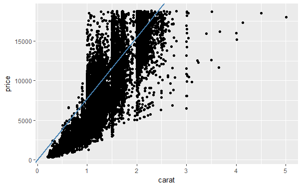

```r
slope <- coef(mod)[2]
diamonds_tidy %>%
  ggplot(aes(x = carat, y = price))+
  geom_point() +
  geom_abline(slope = slope, colour = "steelblue", size = 1)
```

```r
diamonds_tidy %>%
  arrange(desc(.hat))%>%
  head()
```

|  | price | carat | .fitted | .se.fit | .resid | .hat | .sigma | .cooksd | .std.resid |
| --- | --- | --- | --- | --- | --- | --- | --- | --- | --- |
| 1 | 18018 | 5.01 | 36603.33 | 59.62327 | -18585.33 | 0.0014824309 | 1546.504 | 0.10708202 | -12.010578 |
| 2 | 18531 | 4.50 | 32647.55 | 52.50045 | -14116.55 | 0.0011493938 | 1547.382 | 0.04786720 | -9.121156 |
| 3 | 17329 | 4.13 | 29777.68 | 47.34257 | -12448.68 | 0.0009346447 | 1547.647 | 0.03025645 | -8.042623 |
| 4 | 15223 | 4.01 | 28846.91 | 45.67202 | -13623.91 | 0.0008698480 | 1547.464 | 0.03372216 | -8.801608 |
| 5 | 15223 | 4.01 | 28846.91 | 45.67202 | -13623.91 | 0.0008698480 | 1547.464 | 0.03372216 | -8.801608 |
| 6 | 15984 | 4.00 | 28769.34 | 45.53287 | -12785.34 | 0.0008645556 | 1547.597 | 0.02951765 | -8.259839 |

```r
diamonds_tidy %>%
  arrange(desc(.cooksd)) %>%
  head()
```

|  | price | carat | .fitted | .se.fit | .resid | .hat | .sigma | .cooksd | .std.resid |
| --- | --- | --- | --- | --- | --- | --- | --- | --- | --- |
| 1 | 18018 | 5.01 | 36603.33 | 59.62327 | -18585.33 | 0.0014824309 | 1546.504 | 0.10708202 | -12.010578 |
| 2 | 18531 | 4.50 | 32647.55 | 52.50045 | -14116.55 | 0.0011493938 | 1547.382 | 0.04786720 | -9.121156 |
| 3 | 15223 | 4.01 | 28846.91 | 45.67202 | -13623.91 | 0.0008698480 | 1547.464 | 0.03372216 | -8.801608 |
| 4 | 15223 | 4.01 | 28846.91 | 45.67202 | -13623.91 | 0.0008698480 | 1547.464 | 0.03372216 | -8.801608 |
| 5 | 17329 | 4.13 | 29777.68 | 47.34257 | -12448.68 | 0.0009346447 | 1547.647 | 0.03025645 | -8.042623 |
| 6 | 11668 | 3.65 | 26054.59 | 40.66903 | -14386.59 | 0.0006897163 | 1547.336 | 0.02980565 | -9.293498 |

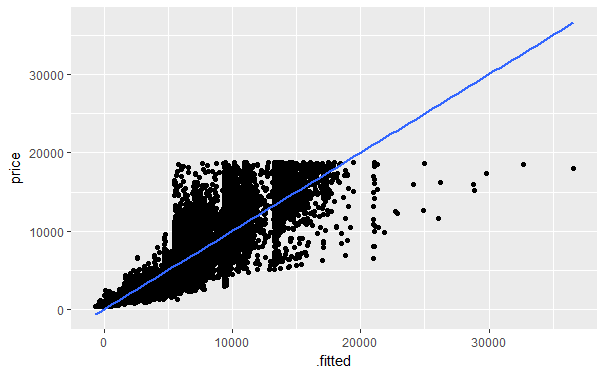

```r
diamonds_tidy %>%
  ggplot(aes(x = .fitted, y = price)) +
  geom_point() +
  geom_smooth(method = "lm")
```